# STA 4102 Homework 3

Kayla Perry

2024-10-23

# Homework 3

## Complete All of the Problems

Complete all of the problems below and enter your code within the supplied code block. If code is already included in the code block, this is for the setup of the problem. If the problem does not have a code component, write your response as a comment in the R code block.

### Problem 1

You are provided with a dataset (`car_data.csv`) that contains information about cars, including their horsepower (`hp`), weight (`wt`), miles per gallon (`mpg`), and the number of cylinders (`cyl`). In addition to analyzing this dataset, simulate new data based on observed trends.

1. **Data Loading**: Load the dataset from the file `car_data.csv` into R using `read.csv`, and visual the first five rows.
2. **Data Simulation**: Simulate additional data for 100 cars based on the distributions of `hp`, `wt`, and `mpg` observed in the original dataset. Use normal distributions with mean and standard deviation computed from the dataset.
3. **Data Visualization**: Create a scatter plot of `hp` vs `mpg` for both the original and simulated datasets. The size of the points should represent the car’s weight (`wt`), and color should differentiate cars with 4, 6, and 8 cylinders.
4. **Function Implementation**: Write a function `simulate_car_data` that generates the simulated data based on the statistics (mean and standard deviation) of the original dataset.
5. **If/Else Logic**: Use an `if/else` statement within the function to print a warning if any simulated values for `hp` or `mpg` are negative.
6. **Loop Implementation**: Use a loop to simulate 5 different sets of car data and compare their summary statistics (mean and standard deviation) with the original dataset.

```r
#Your codes here
#1.
library(readr)
car_data <- read_csv("~/OneDrive - University of South Florida/STA4102/car_data.csv")
head(car_data, 5)
```

```
## # A tibble: 5 × 4
##     mpg    hp    wt   cyl
##   <dbl> <dbl> <dbl> <dbl>
## 1  21     110  2.62     6
## 2  21     110  2.88     6
## 3  22.8    93  2.32     4
## 4  21.4   110  3.22     6
## 5  18.7   175  3.44     8
```

[output not shown]

[output not shown]

```r
#4.
simulate_car_data <- function(df){
  mean_mpg <- mean(df$mpg, na.rm = TRUE)
  sd_mpg <- sd(df$mpg, na.rm = TRUE)
  simulate_mpg <- round(rnorm(100, mean = mean_mpg, sd = sd_mpg), 1)

  mean_hp <- mean(df$hp, na.rm = TRUE)
  sd_hp <- sd(df$hp, na.rm = TRUE)
  simulate_hp <- round(rnorm(100, mean = mean_hp, sd = sd_hp))

  mean_wt <- mean(df$wt, na.rm = TRUE)
  sd_wt <- sd(df$wt, na.rm = TRUE)
  simulate_wt <- round(rnorm(100, mean = mean_wt, sd = sd_wt), 3)

  mean_cyl <- mean(df$cyl, na.rm = TRUE)
  sd_cyl <- sd(df$cyl, na.rm = TRUE)
  simulate_cyl <- sample(c(4,6,8), size = 100, replace = TRUE)

  simulated_data <- data.frame(mpg = simulate_mpg,
                               hp = simulate_hp,
                               wt = simulate_wt,
                               cyl = simulate_cyl)
  return(simulated_data)}
```

```r
simulate_car_data(car_data)
```

```
##      mpg  hp    wt cyl
## 1   20.0 118 2.651   8
## 2   19.5  87 2.075   8
## 3   19.5  26 2.375   6
## 4   20.3 123 3.906   8
## 5   17.9  63 2.651   6
## 6   20.1 129 3.100   8
## 7   17.5 110 3.234   4
## 8   15.0 147 4.134   6
## 9   20.7 115 3.880   6
## 10  15.7 154 3.226   4
## 11  19.6  92 2.631   4
## 12  20.4 188 3.082   4
## 13  17.6  -9 2.899   8
## 14  11.4  97 3.207   6
```

[output cut: 86 more lines]

```r
#5.
simulate_car_data <- function(df){
  if (any(df$mpg<0 )){
    print("Warning values for mpg are negative.")
  }
  if (any(df$hp<0)){
    print("Warning values for hp or mpg are negative.")
  }
  mean_mpg <- mean(df$mpg, na.rm = TRUE)
  sd_mpg <- sd(df$mpg, na.rm = TRUE)
  simulate_mpg <- round(rnorm(100, mean = mean_mpg, sd = sd_mpg), 1)

  mean_hp <- mean(df$hp, na.rm = TRUE)
  sd_hp <- sd(df$hp, na.rm = TRUE)
  simulate_hp <- round(rnorm(100, mean = mean_hp, sd = sd_hp))

  mean_wt <- mean(df$wt, na.rm = TRUE)
  sd_wt <- sd(df$wt, na.rm = TRUE)
  simulate_wt <- round(rnorm(100, mean = mean_wt, sd = sd_wt), 3)

  mean_cyl <- mean(df$cyl, na.rm = TRUE)
  sd_cyl <- sd(df$cyl, na.rm = TRUE)
  simulate_cyl <- sample(c(4,6,8), size = 100, replace = TRUE)

  simulated_data <- data.frame(mpg = simulate_mpg,
                               hp = simulate_hp,
                               wt = simulate_wt,
                               cyl = simulate_cyl)
  return(simulated_data)}
simulate_car_data(car_data)
```

```
##      mpg  hp    wt cyl
## 1   20.8 -15 2.508   4
## 2   21.3 174 2.971   4
## 3   19.9 200 2.943   8
## 4   21.6 126 2.136   8
## 5   24.6  96 1.881   6
## 6   20.5 196 3.358   6
## 7   19.4 169 2.324   8
## 8   16.9  65 2.917   6
## 9   21.4 156 2.601   6
## 10  13.7 261 2.493   4
## 11  16.6 123 2.977   4
## 12  27.2 135 3.149   6
## 13  21.1  76 4.032   6
## 14  22.4  26 3.009   6
```

[output cut: 86 more lines]

```r
#6.****
simulate_car_data <- function(df){
    if (any(df$mpg<0 )){
      print("Warning values for mpg are negative.")
    }
    if (any(df$hp<0)){
      print("Warning values for hp or mpg are negative.")
    }
    mean_mpg <- mean(df$mpg, na.rm = TRUE)
    sd_mpg <- sd(df$mpg, na.rm = TRUE)
    simulate_mpg <- round(rnorm(100, mean = mean_mpg, sd = sd_mpg), 1)

    mean_hp <- mean(df$hp, na.rm = TRUE)
    sd_hp <- sd(df$hp, na.rm = TRUE)
    simulate_hp <- round(rnorm(100, mean = mean_hp, sd = sd_hp))

    mean_wt <- mean(df$wt, na.rm = TRUE)
    sd_wt <- sd(df$wt, na.rm = TRUE)
    simulate_wt <- round(rnorm(100, mean = mean_wt, sd = sd_wt), 3)

    mean_cyl <- mean(df$cyl, na.rm = TRUE)
    sd_cyl <- sd(df$cyl, na.rm = TRUE)
    simulate_cyl <- sample(c(4,6,8), size = 100, replace = TRUE)

    simulated_data <- data.frame(mpg = simulate_mpg,
                                 hp = simulate_hp,
                                 wt = simulate_wt,
                                 cyl = simulate_cyl)
    return(simulated_data)}
simulate_car_data(car_data)
```

```
##      mpg  hp    wt cyl
## 1   23.5 158 4.003   6
## 2   20.5 133 2.969   4
## 3   24.1  70 3.381   6
## 4   25.3 124 2.960   8
## 5   18.2 122 2.721   8
## 6   20.6 153 3.748   8
## 7   17.4 112 2.432   4
## 8   18.6 169 2.784   8
## 9   24.2 156 2.833   8
## 10  21.5  21 1.916   6
## 11  16.0 134 2.837   4
## 12  21.6  54 3.644   8
## 13  17.0 139 2.596   6
## 14  24.5 154 3.205   8
```

[output cut: 86 more lines]

### Problem 2

You are provided with a dataset (`customer_purchase_data.csv`) that simulates whether 1000 customers made a purchase (1 = Purchase, 0 = No Purchase). Additionally, simulate the decisions for a future marketing campaign based on the current data.

1. **Data Loading**: Load the dataset from the file `customer_purchase_data.csv` into R, and visual the first five rows.
2. **Data Simulation**: Simulate the purchase decisions for 500 new customers, assuming the probability of purchase remains the same as observed in the original dataset (i.e., use the proportion of 1’s from the original dataset).
3. **Function with Conditional Logic**: Write a function `analyze_purchases` that takes the purchase decisions (both original and simulated) and returns the total number of purchases and the proportion of customers who made a purchase. *Note:* If the proportion of purchases is greater than 50%, return “Successful Campaign”, otherwise return “Campaign Needs Improvement”.
4. **Loop Implementation**: Simulate the purchase decisions for 5 different regions (each with 500 customers) and store the total purchases for each region.
5. **Data Visualization**: Create a bar plot of the total purchases for each region based on the simulations.

```r
#Your codes here
#1.
library(readr)
customer_purchase_data <- read_csv("~/OneDrive - University of South Florida/STA4102/customer_purchase_data.csv")
head(customer_purchase_data, 5)
```

```
## # A tibble: 5 × 1
##   Purchase
##      <dbl>
## 1        0
## 2        0
## 3        1
## 4        1
## 5        0
```

```r
str(customer_purchase_data)
```

```
## spc_tbl_ [1,000 × 1] (S3: spec_tbl_df/tbl_df/tbl/data.frame)
##  $ Purchase: num [1:1000] 0 0 1 1 0 0 0 0 0 0 ...
##  - attr(*, "spec")=
##   .. cols(
##   ..   Purchase = col_double()
##   .. )
##  - attr(*, "problems")=<externalptr>
```

```r
#2.
num_ones <- sum(customer_purchase_data)
num_ones
```

```
## [1] 414
```

```r
prop_ones <- num_ones/1000
prop_ones
```

```
## [1] 0.414
```

```r
simulated_purchases <- rbinom(500, size = 1, prob = prop_ones)
simulated_purchase <- data.frame(simulated_purchases)
print(simulated_purchase)
```

```
##     simulated_purchases
## 1                     0
## 2                     1
## 3                     1
## 4                     1
## 5                     0
## 6                     0
## 7                     0
## 8                     0
## 9                     1
## 10                    1
## 11                    0
## 12                    0
## 13                    0
## 14                    1
```

[output cut: 486 more lines]

```r
#3.
analyze_purchases <- function(customer_purchase_data, simulated_purchase){

  colnames(simulated_purchase) <- colnames(customer_purchase_data)

  combined_data <- rbind(customer_purchase_data, simulated_purchase)

  num_rows <- nrow(combined_data)
  num_purchases <- sum(combined_data)

  prop_purchases <- num_purchases / num_rows

  if(prop_purchases > 0.5){
    result <- "Successful Campaign"
  } else {
    result <- "Campaign Needs Improvement"
  }

  return(list("Total Purchases" = num_purchases, "Proportion" = prop_purchases, "Result" = result))
}

analyze_purchases(customer_purchase_data, simulated_purchase)
```

```
## $`Total Purchases`
## [1] 617
##
## $Proportion
## [1] 0.4113333
##
## $Result
## [1] "Campaign Needs Improvement"
```

```r
#4.
set.seed(42)

simulate_purchases <- function(num_customers) {
  sample(c(0, 1), size = num_customers, replace = TRUE, prob = c(0.5, 0.5))
}

num_customers <- 500
num_regions <- 5

total_purchases <- numeric(num_regions)

for (i in 1:num_regions) {
  purchases <- simulate_purchases(num_customers)

  total_purchases[i] <- sum(purchases)

  cat("Total purchases for Region", i, ":", total_purchases[i], "\n")
}
```

```
## Total purchases for Region 1 : 265
## Total purchases for Region 2 : 262
## Total purchases for Region 3 : 256
## Total purchases for Region 4 : 240
## Total purchases for Region 5 : 234
```

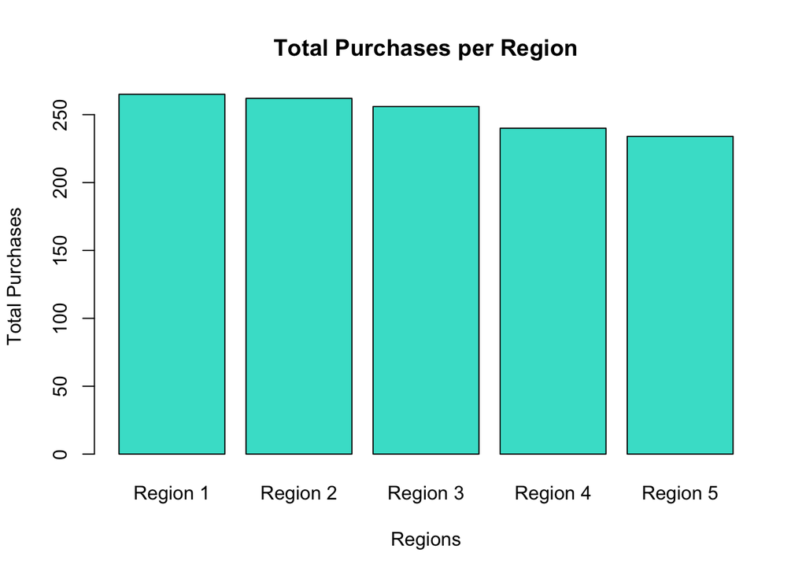

```r
#5.
region_names <- c("Region 1", "Region 2", "Region 3", "Region 4", "Region 5")

# Create a bar plot of total purchases
barplot(total_purchases,
        names.arg = region_names,
        main = "Total Purchases per Region",
        xlab = "Regions",
        ylab = "Total Purchases",
        col = "turquoise")
```

### Problem 3

You are given a dataset (`temperature_data.csv`) that contains simulated daily temperatures (in Fahrenheit) for 30 days. Your task is to simulate additional weather data based on the observed temperatures and categorize the days based on temperature.

1. **Data Loading**: Load the dataset from the file `temperature_data.csv` into R, and visual the first five rows.
2. **Data Simulation**: Simulate temperature data for the next 30 days based on the mean and standard deviation of the original 30 days of data.
3. **Function Implementation**: Write a function `categorize_temperature` that takes a vector of temperatures (original and simulated) as input and categorizes each day as “Cold” (below 60°F), “Warm” (60°F–80°F), or “Hot” (above 80°F).
4. **If/Else Logic**: Handle edge cases where temperatures are exactly 60°F or 80°F by categorizing them as “Warm”.
5. **Loop**: Use a `for` loop to count how many days in both the original and simulated data fall into each category.
6. **Data Visualization**: Create a bar plot showing the number of “Cold”, “Warm”, and “Hot” days for both the original and simulated data.

```r
#Your codes here
#1.
library(readr)
temperature_data <- read_csv("~/OneDrive - University of South Florida/STA4102/temperature_data.csv")
head(temperature_data, 5)
```

```
## # A tibble: 5 × 1
##   Temperature
##         <dbl>
## 1        70.4
## 2        66.7
## 3        58.8
## 4        73.6
## 5        76.5
```

```r
#2.
mean_temp <- mean(temperature_data$Temperature, na.rm = TRUE)
sd_temp <- sd(temperature_data$Temperature, na.rm = TRUE)
simulate_temp <- round(rnorm(30, mean = mean_temp, sd = sd_temp), 1)

simulated_temp <- data.frame(Simulated_Temperature = simulate_temp)
head(simulated_temp)
```

```
##   Simulated_Temperature
## 1                  50.5
## 2                  63.5
## 3                  87.6
## 4                  63.2
## 5                  54.8
## 6                  68.3
```

```r
str(simulated_temp)
```

```
## 'data.frame':    30 obs. of  1 variable:
##  $ Simulated_Temperature: num  50.5 63.5 87.6 63.2 54.8 68.3 81.8 50.2 65 73.1 ...
```

```r
#3 & #4
categorize_temperature <- function(temperature_data, simulated_temp){

  temperature_data <- as.vector(unlist(temperature_data))
  simulated_temp <- as.vector(unlist(simulated_temp))

  combined_temps <- c(temperature_data, simulated_temp)

  categories <- ifelse(combined_temps < 60, "Cold",
                ifelse(combined_temps >= 60 & combined_temps <= 80, "Warm", "Hot"))

  return(categories)
}

categorized_temperatures <- categorize_temperature(temperature_data, simulated_temp)

print(categorized_temperatures)
```

```
##  [1] "Warm" "Warm" "Cold" "Warm" "Warm" "Warm" "Cold" "Warm" "Warm" "Warm"
## [11] "Hot"  "Warm" "Warm" "Cold" "Hot"  "Warm" "Warm" "Warm" "Cold" "Warm"
## [21] "Warm" "Warm" "Warm" "Warm" "Cold" "Cold" "Cold" "Warm" "Cold" "Hot"
## [31] "Cold" "Warm" "Hot"  "Warm" "Cold" "Warm" "Hot"  "Cold" "Warm" "Warm"
## [41] "Hot"  "Warm" "Hot"  "Warm" "Cold" "Cold" "Warm" "Warm" "Warm" "Warm"
## [51] "Warm" "Warm" "Warm" "Cold" "Cold" "Warm" "Warm" "Hot"  "Warm" "Warm"
```

```r
#5. & #6.
categorize_temperature <- function(temperature_data, simulated_temp){

  # Convert input data to vectors
  temperature_data <- as.vector(unlist(temperature_data))
  simulated_temp <- as.vector(unlist(simulated_temp))

  # Combine temperature data
  combined_temps <- c(temperature_data, simulated_temp)

  # Categorize temperatures
  categories <- ifelse(combined_temps < 60, "Cold",
                ifelse(combined_temps >= 60 & combined_temps <= 80, "Warm", "Hot"))

  # Count occurrences of each category
  category_count <- table(categories)

  # Return the count of categories
  return(category_count)
}

category_counts <- categorize_temperature(temperature_data, simulated_temp)

print(category_counts)
```

```
## categories
## Cold  Hot Warm
##   15    8   37
```

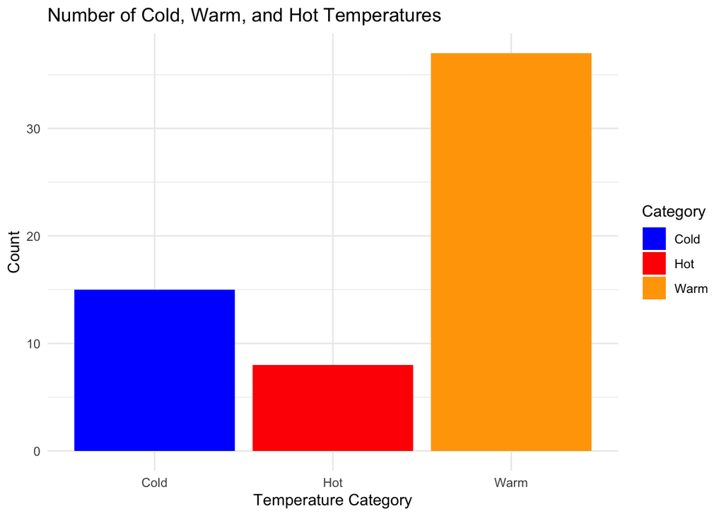

```r
category_df <- as.data.frame(category_counts)
colnames(category_df) <- c("Category", "Count")

library(ggplot2)

ggplot(category_df, aes(x = Category, y = Count, fill = Category)) +
  geom_bar(stat = "identity") +
  scale_fill_manual(values = c("Cold" = "blue", "Warm" = "orange", "Hot" = "red")) +  # Set custom colors
  labs(title = "Number of Cold, Warm, and Hot Temperatures",
       x = "Temperature Category",
       y = "Count") +
  theme_minimal()
```

### Problem 4

You are given a dataset (`insurance_claims_data.csv`) that contains the number of claims per customer and the total claim cost for 1000 customers. In addition to analyzing the given data, simulate additional claim data for new customers.

1. **Data Loading**: Load the dataset from the file `insurance_claims_data.csv` into R, and visual the first five rows.
2. **Data Simulation**: Simulate the number of claims and the total claim cost for 500 new customers. Assume the number of claims follows the same Poisson distribution and the claim amounts follow the same Gamma distribution as in the original data.
3. **Function Implementation**: Write a function `simulate_claims` that generates new claim data (both number of claims and claim amounts) based on the original dataset’s statistics.
4. **If/Else Logic**: Modify the function to print a warning if the total claims for any customer exceed $50,000.
5. **Loop Implementation**: Simulate the total claim costs for the new customers and compare their statistics with those of the original dataset.
6. **Data Visualization**: Create histograms for the total claim costs, comparing the original and simulated data.

```r
#Your codes here
#1.
library(readr)
insurance_claims_data <- read_csv("~/OneDrive - University of South Florida/STA4102/insurance_claims_data.csv")
head(insurance_claims_data, 5)
```

```
## # A tibble: 5 × 3
##   Customer_ID Number_of_Claims Total_Claim_Cost
##         <dbl>            <dbl>            <dbl>
## 1           1                2            9968.
## 2           2                3            4371.
## 3           3                2            3831.
## 4           4                5           10560.
## 5           5                2            1983.
```

```r
#2.Simulate the number of claims and the total claim cost for 500 new customers. Assume the number of claims follows the same Poisson distribution and the claim amounts follow the same Gamma distribution as in the original data.
set.seed(42)

mean_cost <- mean(insurance_claims_data$Total_Claim_Cost)
variance_cost <- var(insurance_claims_data$Total_Claim_Cost)

shape_estimate <- (mean_cost^2) / variance_cost
scale_estimate <- variance_cost / mean_cost

lambda_estimate <- mean(insurance_claims_data$Number_of_Claims)  # Poisson lambda
new_number_of_claims <- rpois(500, lambda = lambda_estimate)


new_total_claim_cost <- rgamma(500, shape = shape_estimate, scale = scale_estimate)

new_customers_data <- data.frame(
  Customer_ID = 1001:1500,
  Number_of_Claims = new_number_of_claims,
  Total_Claim_Cost = new_total_claim_cost
)

head(new_customers_data)
```

```
##   Customer_ID Number_of_Claims Total_Claim_Cost
## 1        1001                6         1483.036
## 2        1002                6         8713.479
## 3        1003                2        10692.727
## 4        1004                5         1580.467
## 5        1005                4         1618.992
## 6        1006                3         3001.739
```

```r
#3. Write a function `simulate_claims` that generates new claim data (both number of claims and claim amounts) based on the original dataset’s statistics.

simulate_claims <- function(insurance_claims_data, num_customers = 500) {

  mean_cost <- mean(insurance_claims_data$Total_Claim_Cost)
variance_cost <- var(insurance_claims_data$Total_Claim_Cost)

shape_estimate <- (mean_cost^2) / variance_cost
scale_estimate <- variance_cost / mean_cost

lambda_estimate <- mean(insurance_claims_data$Number_of_Claims)  # Poisson lambda
new_number_of_claims <- rpois(500, lambda = lambda_estimate)


new_total_claim_cost <- rgamma(500, shape = shape_estimate, scale = scale_estimate)

new_customers_data <- data.frame(
  Customer_ID = 1001:1500,
  Number_of_Claims = new_number_of_claims,
  Total_Claim_Cost = new_total_claim_cost
)

  return(new_customers_data)
}

new_customers_data <- simulate_claims(insurance_claims_data)

head(new_customers_data)
```

```
##   Customer_ID Number_of_Claims Total_Claim_Cost
## 1        1001                5         8862.444
## 2        1002                3        16098.308
## 3        1003                2         9135.457
## 4        1004                5        11638.810
## 5        1005                4         5960.999
## 6        1006                3         1399.703
```

```r
#4.
simulate_claims <- function(insurance_claims_data, num_customers = 500) {

  mean_cost <- mean(insurance_claims_data$Total_Claim_Cost)
variance_cost <- var(insurance_claims_data$Total_Claim_Cost)

shape_estimate <- (mean_cost^2) / variance_cost
scale_estimate <- variance_cost / mean_cost

lambda_estimate <- mean(insurance_claims_data$Number_of_Claims)  # Poisson lambda
new_number_of_claims <- rpois(500, lambda = lambda_estimate)


new_total_claim_cost <- rgamma(500, shape = shape_estimate, scale = scale_estimate)

new_customers_data <- data.frame(
  Customer_ID = 1001:1500,
  Number_of_Claims = new_number_of_claims,
  Total_Claim_Cost = new_total_claim_cost
)
  exceeding_customers <- new_customers_data$Total_Claim_Cost > 50000
  if (any(exceeding_customers)) {
    warning("Total claim costs for some customers exceed $50,000!")
    # Print the IDs of customers with high claims
    high_claims_indices <- which(exceeding_customers)
    print(paste("Customer IDs with claims over $50,000:", (1000 + high_claims_indices)))  #
  }

  return(new_customers_data)
}

new_customers_data <- simulate_claims(insurance_claims_data)

head(new_customers_data)
```

```
##   Customer_ID Number_of_Claims Total_Claim_Cost
## 1        1001                4         2366.850
## 2        1002                4         8165.190
## 3        1003                2         4304.490
## 4        1004                2         2413.558
## 5        1005                2        11326.839
## 6        1006                2         1881.411
```

```r
#5.

new_customers_data <- simulate_claims(insurance_claims_data)

print(head(new_customers_data))
```

```
##   Customer_ID Number_of_Claims Total_Claim_Cost
## 1        1001                4        10994.991
## 2        1002                4         3062.466
## 3        1003                6         3637.250
## 4        1004                1        10284.243
## 5        1005                7         4064.763
## 6        1006                0         4190.369
```

```r
original_mean_claims <- mean(insurance_claims_data$Number_of_Claims)
original_var_claims <- var(insurance_claims_data$Number_of_Claims)
original_mean_cost <- mean(insurance_claims_data$Total_Claim_Cost)
original_var_cost <- var(insurance_claims_data$Total_Claim_Cost)
original_min_cost <- min(insurance_claims_data$Total_Claim_Cost)
original_max_cost <- max(insurance_claims_data$Total_Claim_Cost)

new_mean_claims <- mean(new_customers_data$Number_of_Claims)
new_var_claims <- var(new_customers_data$Number_of_Claims)
new_mean_cost <- mean(new_customers_data$Total_Claim_Cost)
new_var_cost <- var(new_customers_data$Total_Claim_Cost)
new_min_cost <- min(new_customers_data$Total_Claim_Cost)
new_max_cost <- max(new_customers_data$Total_Claim_Cost)

comparison_stats <- data.frame(
  Statistic = c("Mean Claims", "Variance Claims", "Mean Cost", "Variance Cost", "Min Cost", "Max Cost"),
  Original = c(original_mean_claims, original_var_claims, original_mean_cost, original_var_cost, original_min_cost, original_max_cost),
  New = c(new_mean_claims, new_var_claims, new_mean_cost, new_var_cost, new_min_cost, new_max_cost)
)

print(comparison_stats)
```

```
##         Statistic     Original          New
## 1     Mean Claims 3.100000e+00 3.004000e+00
## 2 Variance Claims 3.157157e+00 3.611206e+00
## 3       Mean Cost 6.283459e+03 6.208170e+03
## 4   Variance Cost 1.931306e+07 1.975327e+07
## 5        Min Cost 0.000000e+00 1.736902e+02
## 6        Max Cost 3.061243e+04 2.742259e+04
```

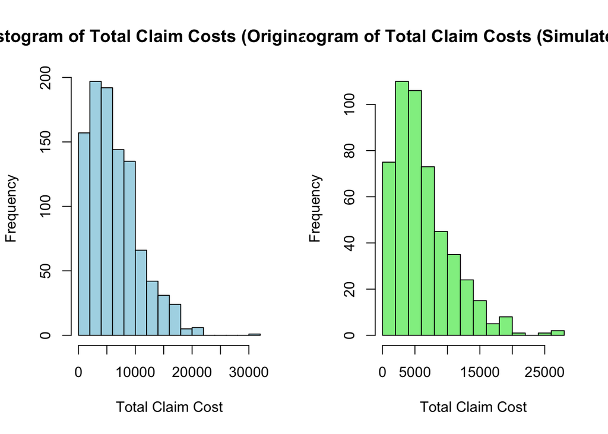

```r
#6.
par(mfrow = c(1, 2))  # Set up the plotting area for 2 plots side by side

# Histogram for original dataset
hist(insurance_claims_data$Total_Claim_Cost,
     main = "Histogram of Total Claim Costs (Original Data)",
     xlab = "Total Claim Cost",
     col = "lightblue")

# Histogram for simulated dataset
hist(new_customers_data$Total_Claim_Cost,
     main = "Histogram of Total Claim Costs (Simulated Data)",
     xlab = "Total Claim Cost",
     col = "lightgreen")
```

```r
# Reset plotting area
par(mfrow = c(1, 1))
```

### Problem 5

You are provided with a dataset (`loan_data.csv`) that contains loan details for 50 customers, including the loan amount, interest rate, and loan term. In addition to analyzing the given data, simulate future loan data for new customers.

1. **Data Loading**: Load the dataset from the file `loan_data.csv` into R, and visual the first five rows.
2. **Data Simulation**: Simulate loan data (loan amount, interest rate, and term) for 100 new customers, using normal distributions for loan amounts, interest rates, and term lengths based on the original dataset.
3. **Function Implementation**: Write a function `calculate_payment` that calculates the monthly payment based on the loan amount, interest rate, and loan term.
4. **If/Else Logic**: Inside the function, check if the interest rate is greater than 0. If not, print a message stating that the loan must have a positive interest rate.
5. **Loop Implementation**: Use a loop to calculate the monthly payments for both the original and simulated loan data.
6. **Data Visualization**: Create a boxplot to visualize the distribution of monthly payments across the original and simulated customers.

```r
#Your codes here
#1.
library(readr)
loan_data <- read_csv("~/OneDrive - University of South Florida/STA4102/loan_data.csv")
head(loan_data, 5)
```

```
## # A tibble: 5 × 4
##   Customer_ID Loan_Amount Interest_Rate Loan_Term_Years
##         <dbl>       <dbl>         <dbl>           <dbl>
## 1           1      34123.        0.0576              16
## 2           2      28851.        0.0584              22
## 3           3      24395.        0.0637              23
## 4           4      22808.        0.0658              19
## 5           5      37897.        0.0729               8
```

```r
str(loan_data)
```

```
## spc_tbl_ [50 × 4] (S3: spec_tbl_df/tbl_df/tbl/data.frame)
##  $ Customer_ID    : num [1:50] 1 2 3 4 5 6 7 8 9 10 ...
##  $ Loan_Amount    : num [1:50] 34123 28851 24395 22808 37897 ...
##  $ Interest_Rate  : num [1:50] 0.0576 0.0584 0.0637 0.0658 0.0729 ...
##  $ Loan_Term_Years: num [1:50] 16 22 23 19 8 20 13 12 11 27 ...
##  - attr(*, "spec")=
##   .. cols(
##   ..   Customer_ID = col_double(),
##   ..   Loan_Amount = col_double(),
##   ..   Interest_Rate = col_double(),
##   ..   Loan_Term_Years = col_double()
##   .. )
##  - attr(*, "problems")=<externalptr>
```

```r
#2.

mean_loan_amount <- mean(loan_data$Loan_Amount)
sd_loan_amount <- sd(loan_data$Loan_Amount)

mean_interest_rate <- mean(loan_data$Interest_Rate)
sd_interest_rate <- sd(loan_data$Interest_Rate)

mean_loan_term <- mean(loan_data$Loan_Term_Years)
sd_loan_term <- sd(loan_data$Loan_Term_Years)

set.seed(42)
simulated_loan_data <- data.frame(
  Customer_ID = 51:150,
  Loan_Amount = rnorm(100, mean = mean_loan_amount, sd = sd_loan_amount),
  Interest_Rate = rnorm(100, mean = mean_interest_rate, sd = sd_interest_rate),
  Loan_Term_Years = round(rnorm(100, mean = mean_loan_term, sd = sd_loan_term))
)

# View the first few rows of the simulated data
head(simulated_loan_data)
```

```
##   Customer_ID Loan_Amount Interest_Rate Loan_Term_Years
## 1          51    46429.73    0.07568326               3
## 2          52    26501.29    0.07360409              18
## 3          53    36053.68    0.04634625              24
## 4          54    38830.71    0.08430155              30
## 5          55    36477.23    0.05082412               7
## 6          56    31222.51    0.06110307               9
```

```r
#3.
calculate_payment <- function(loan_amount, annual_interest_rate, loan_term_years) {
  monthly_interest_rate <- annual_interest_rate / 12
  total_payments <- loan_term_years * 12

  monthly_payment <- loan_amount * (monthly_interest_rate * (1 + monthly_interest_rate)^total_payments) /
                     ((1 + monthly_interest_rate)^total_payments - 1)

  return(monthly_payment)
}

simulated_loan_data$Monthly_Payment <- mapply(calculate_payment,
                                                simulated_loan_data$Loan_Amount,
                                                simulated_loan_data$Interest_Rate,
                                                simulated_loan_data$Loan_Term_Years)

head(simulated_loan_data)
```

```
##   Customer_ID Loan_Amount Interest_Rate Loan_Term_Years Monthly_Payment
## 1          51    46429.73    0.07568326               3       1445.7107
## 2          52    26501.29    0.07360409              18        221.7344
## 3          53    36053.68    0.04634625              24        207.6761
## 4          54    38830.71    0.08430155              30        296.6546
## 5          55    36477.23    0.05082412               7        516.9796
## 6          56    31222.51    0.06110307               9        376.5551
```

```r
#4.
calculate_payment <- function(loan_amount, annual_interest_rate, loan_term_years) {

  if (annual_interest_rate <= 0) {
    message("The loan must have a positive interest rate.")
    return(NA)
  }

  monthly_interest_rate <- annual_interest_rate / 12
  total_payments <- loan_term_years * 12

  monthly_payment <- loan_amount * (monthly_interest_rate * (1 + monthly_interest_rate)^total_payments) /
                     ((1 + monthly_interest_rate)^total_payments - 1)

  return(monthly_payment)
}

simulated_loan_data$Monthly_Payment <- mapply(calculate_payment,
                                                simulated_loan_data$Loan_Amount,
                                                simulated_loan_data$Interest_Rate,
                                                simulated_loan_data$Loan_Term_Years)

head(simulated_loan_data)
```

```
##   Customer_ID Loan_Amount Interest_Rate Loan_Term_Years Monthly_Payment
## 1          51    46429.73    0.07568326               3       1445.7107
## 2          52    26501.29    0.07360409              18        221.7344
## 3          53    36053.68    0.04634625              24        207.6761
## 4          54    38830.71    0.08430155              30        296.6546
## 5          55    36477.23    0.05082412               7        516.9796
## 6          56    31222.51    0.06110307               9        376.5551
```

```r
#5.
loan_data$Monthly_Payment <- NA
for (i in 1:nrow(loan_data)) {
  loan_data$Monthly_Payment[i] <- calculate_payment(loan_data$Loan_Amount[i],
                                                    loan_data$Interest_Rate[i],
                                                    loan_data$Loan_Term_Years[i])
}

mean_loan_amount <- mean(loan_data$Loan_Amount)
sd_loan_amount <- sd(loan_data$Loan_Amount)

mean_interest_rate <- mean(loan_data$Interest_Rate)
sd_interest_rate <- sd(loan_data$Interest_Rate)

mean_loan_term <- mean(loan_data$Loan_Term_Years)
sd_loan_term <- sd(loan_data$Loan_Term_Years)

set.seed(42)

simulated_loan_data$Monthly_Payment <- NA
for (i in 1:nrow(simulated_loan_data)) {
  simulated_loan_data$Monthly_Payment[i] <- calculate_payment(simulated_loan_data$Loan_Amount[i],
                                                                simulated_loan_data$Interest_Rate[i],
                                                                simulated_loan_data$Loan_Term_Years[i])
}

head(loan_data)
```

```
## # A tibble: 6 × 5
##   Customer_ID Loan_Amount Interest_Rate Loan_Term_Years Monthly_Payment
##         <dbl>       <dbl>         <dbl>           <dbl>           <dbl>
## 1           1      34123.        0.0576              16           272.
## 2           2      28851.        0.0584              22           194.
## 3           3      24395.        0.0637              23           169.
## 4           4      22808.        0.0658              19           175.
## 5           5      37897.        0.0729               8           522.
## 6           6      11813.        0.0788              20            97.9
```

```r
head(simulated_loan_data)
```

```
##   Customer_ID Loan_Amount Interest_Rate Loan_Term_Years Monthly_Payment
## 1          51    46429.73    0.07568326               3       1445.7107
## 2          52    26501.29    0.07360409              18        221.7344
## 3          53    36053.68    0.04634625              24        207.6761
## 4          54    38830.71    0.08430155              30        296.6546
## 5          55    36477.23    0.05082412               7        516.9796
## 6          56    31222.51    0.06110307               9        376.5551
```

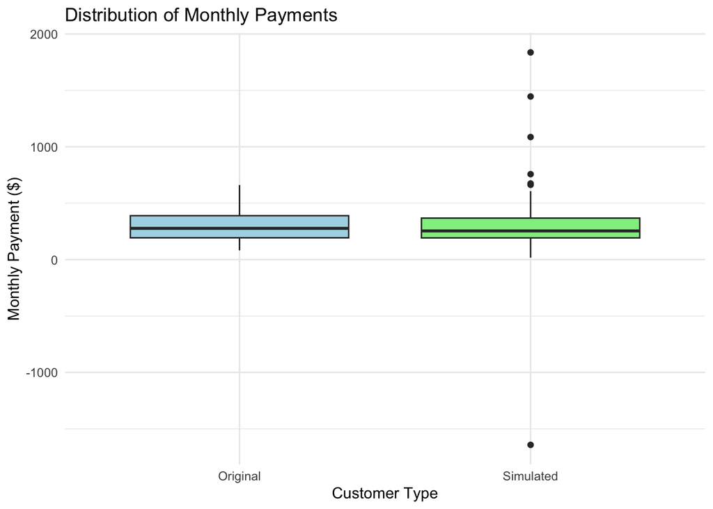

```r
#6.
loan_data$Type <- "Original"
simulated_loan_data$Type <- "Simulated"

combined_data <- rbind(loan_data[, c("Monthly_Payment", "Type")],
                        simulated_loan_data[, c("Monthly_Payment", "Type")])

ggplot(combined_data, aes(x = Type, y = Monthly_Payment)) +
  geom_boxplot(fill = c("lightblue", "lightgreen")) +
  labs(title = "Distribution of Monthly Payments",
       x = "Customer Type",
       y = "Monthly Payment ($)") +
  theme_minimal()
```

### Problem 6

You are provided with a dataset (`sales_forecasting_data.csv`) that contains simulated sales data for the next 12 months, including base sales, the effect of marketing campaigns, and the adjusted sales values. In addition to analyzing the provided data, simulate sales data under different marketing conditions.

1. **Data Loading**: Load the dataset from the file `sales_forecasting_data.csv` into R, and visual the first five rows.
2. **Data Simulation**: Simulate base sales for the next 12 months using a normal distribution, with the same mean and standard deviation as the original base sales data. Simulate the marketing campaign’s effect for 5 different campaigns (use a loop to simulate different effects).
3. **Function Implementation**: Write a function `simulate_sales` that adjusts the base sales based on the marketing campaign’s effect (boost or reduce sales by 10%).
4. **Loop Implementation**: Simulate the monthly sales for 5 different campaigns and calculate the average sales for each campaign.
5. **Data Visualization**: Plot the average monthly sales over time for each of the 5 simulated campaigns, and add error bars to show the variability across simulations.

```r
#Your codes here
#1.
library(readr)
sales_forecasting_data <- read_csv("~/OneDrive - University of South Florida/STA4102/sales_forecasting_data.csv")
head(sales_forecasting_data, 5)
```

```
## # A tibble: 5 × 4
##   Month Base_Sales Marketing_Effect Adjusted_Sales
##   <dbl>      <dbl>            <dbl>          <dbl>
## 1     1     12140.             -0.1         10926.
## 2     2     12326.             -0.1         11094.
## 3     3     10645.              0.1         11709.
## 4     4      7375.             -0.1          6638.
## 5     5     10146.             -0.1          9132.
```

```r
#2.
mean_base_sales <- mean(sales_forecasting_data$Base_Sales)
sd_base_sales <- sd(sales_forecasting_data$Base_Sales)

set.seed(42)

new_months <- 6:17
simulated_base_sales <- rnorm(12, mean = mean_base_sales, sd = sd_base_sales)

simulated_sales_data <- data.frame(
  Month = new_months,
  Base_Sales = simulated_base_sales,
  Marketing_Effect = NA,
  Adjusted_Sales = NA
)

for (campaign in 1:5) {
  marketing_effect <- runif(12, min = -0.2, max = 0.2)  # Random marketing effect between -0.2 and 0.2
  simulated_sales_data$Marketing_Effect <- marketing_effect
  simulated_sales_data$Adjusted_Sales <- simulated_sales_data$Base_Sales * (1 + simulated_sales_data$Marketing_Effect)

  cat("Campaign", campaign, "\n")
  print(simulated_sales_data)
  cat("\n")
}
```

```
## Campaign 1
##    Month Base_Sales Marketing_Effect Adjusted_Sales
## 1      6  12557.721     -0.167024977      10460.268
## 2      7   9378.579      0.005684714       9431.893
## 3      8  10902.451     -0.043918613      10423.630
## 4      9  11345.465      0.162295252      13186.780
## 5     10  10970.019     -0.021212149      10737.322
## 6     11  10131.745      0.134401704      11493.468
## 7     12  12788.584      0.095038247      14003.989
## 8     13  10150.576      0.124422057      11413.531
## 9     14  13621.125     -0.044756687      13011.488
## 10    15  10203.042      0.074067892      10958.760
## 11    16  12449.176     -0.198420664       9979.002
## 12    17  14061.655      0.133166432      15934.195
##
```

[output cut: 59 more lines]

```r
#3.
simulate_sales <- function(base_sales, marketing_effect) {
  if (marketing_effect > 0) {
    adjusted_sales <- base_sales * (1 + 0.10)
  } else {
    adjusted_sales <- base_sales * (1 - 0.10)
  }
  return(adjusted_sales)
}

for (i in 1:nrow(sales_forecasting_data)) {
  sales_forecasting_data$Adjusted_Sales[i] <- simulate_sales(sales_forecasting_data$Base_Sales[i],
                                                               sales_forecasting_data$Marketing_Effect[i])
}

print(sales_forecasting_data)
```

```
## # A tibble: 12 × 4
##    Month Base_Sales Marketing_Effect Adjusted_Sales
##    <dbl>      <dbl>            <dbl>          <dbl>
##  1     1     12140.             -0.1         10926.
##  2     2     12326.             -0.1         11094.
##  3     3     10645.              0.1         11709.
##  4     4      7375.             -0.1          6638.
##  5     5     10146.             -0.1          9132.
##  6     6     12100.              0.1         13310.
##  7     7      9719.              0.1         10691.
##  8     8      8893.             -0.1          8004.
##  9     9      8532.             -0.1          7679.
## 10    10     12294.              0.1         13524.
## 11    11      9420.              0.1         10362.
## 12    12     10081.              0.1         11089.
```

```r
mean_base_sales <- mean(sales_forecasting_data$Base_Sales)
sd_base_sales <- sd(sales_forecasting_data$Base_Sales)

set.seed(42)

new_months <- 6:17
simulated_base_sales <- rnorm(12, mean = mean_base_sales, sd = sd_base_sales)

simulated_sales_data <- data.frame(
  Month = new_months,
  Base_Sales = simulated_base_sales,
  Marketing_Effect = NA,
  Adjusted_Sales = NA
)

for (campaign in 1:5) {
  marketing_effect <- runif(12, min = -0.2, max = 0.2)
  simulated_sales_data$Marketing_Effect <- marketing_effect

  for (i in 1:nrow(simulated_sales_data)) {
    simulated_sales_data$Adjusted_Sales[i] <- simulate_sales(simulated_sales_data$Base_Sales[i],
                                                               simulated_sales_data$Marketing_Effect[i])
  }

  cat("Campaign", campaign, "\n")
  print(simulated_sales_data)
  cat("\n")
}
```

```
## Campaign 1
##    Month Base_Sales Marketing_Effect Adjusted_Sales
## 1      6  12557.721     -0.167024977      11301.949
## 2      7   9378.579      0.005684714      10316.436
## 3      8  10902.451     -0.043918613       9812.206
## 4      9  11345.465      0.162295252      12480.011
## 5     10  10970.019     -0.021212149       9873.017
## 6     11  10131.745      0.134401704      11144.919
## 7     12  12788.584      0.095038247      14067.443
## 8     13  10150.576      0.124422057      11165.633
## 9     14  13621.125     -0.044756687      12259.012
## 10    15  10203.042      0.074067892      11223.347
## 11    16  12449.176     -0.198420664      11204.259
## 12    17  14061.655      0.133166432      15467.820
##
```

[output cut: 59 more lines]

```r
#4.

simulate_sales <- function(base_sales, marketing_effect) {
  if (marketing_effect > 0) {
    adjusted_sales <- base_sales * (1 + 0.10)
  } else {
    adjusted_sales <- base_sales * (1 - 0.10)
  }
  return(adjusted_sales)
}

for (i in 1:nrow(sales_forecasting_data)) {
  sales_forecasting_data$Adjusted_Sales[i] <- simulate_sales(sales_forecasting_data$Base_Sales[i],
                                                               sales_forecasting_data$Marketing_Effect[i])
}

print("Original Sales Data with Adjusted Sales:")
```

```
## [1] "Original Sales Data with Adjusted Sales:"
```

```r
print(sales_forecasting_data)
```

```
## # A tibble: 12 × 4
##    Month Base_Sales Marketing_Effect Adjusted_Sales
##    <dbl>      <dbl>            <dbl>          <dbl>
##  1     1     12140.             -0.1         10926.
##  2     2     12326.             -0.1         11094.
##  3     3     10645.              0.1         11709.
##  4     4      7375.             -0.1          6638.
##  5     5     10146.             -0.1          9132.
##  6     6     12100.              0.1         13310.
##  7     7      9719.              0.1         10691.
##  8     8      8893.             -0.1          8004.
##  9     9      8532.             -0.1          7679.
## 10    10     12294.              0.1         13524.
## 11    11      9420.              0.1         10362.
## 12    12     10081.              0.1         11089.
```

```r
mean_base_sales <- mean(sales_forecasting_data$Base_Sales)
sd_base_sales <- sd(sales_forecasting_data$Base_Sales)


set.seed(42)

new_months <- 6:17
simulated_base_sales <- rnorm(12, mean = mean_base_sales, sd = sd_base_sales)

simulated_sales_data <- data.frame(
  Month = new_months,
  Base_Sales = simulated_base_sales,
  Marketing_Effect = NA,
  Adjusted_Sales = NA
)

average_sales_per_campaign <- numeric(5)

for (campaign in 1:5) {
  marketing_effect <- runif(12, min = -0.1, max = 0.1)
  simulated_sales_data$Marketing_Effect <- marketing_effect

  for (i in 1:nrow(simulated_sales_data)) {
    simulated_sales_data$Adjusted_Sales[i] <- simulate_sales(simulated_sales_data$Base_Sales[i],
                                                               simulated_sales_data$Marketing_Effect[i])
  }

  average_sales_per_campaign[campaign] <- mean(simulated_sales_data$Adjusted_Sales, na.rm = TRUE)

  cat("Campaign", campaign, "\n")
  print(simulated_sales_data)
  cat("Average Adjusted Sales:", average_sales_per_campaign[campaign], "\n\n")
}
```

```
## Campaign 1
##    Month Base_Sales Marketing_Effect Adjusted_Sales
## 1      6  12557.721     -0.083512488      11301.949
## 2      7   9378.579      0.002842357      10316.436
## 3      8  10902.451     -0.021959307       9812.206
## 4      9  11345.465      0.081147626      12480.011
## 5     10  10970.019     -0.010606074       9873.017
## 6     11  10131.745      0.067200852      11144.919
## 7     12  12788.584      0.047519124      14067.443
## 8     13  10150.576      0.062211028      11165.633
## 9     14  13621.125     -0.022378343      12259.012
## 10    15  10203.042      0.037033946      11223.347
## 11    16  12449.176     -0.099210332      11204.259
## 12    17  14061.655      0.066583216      15467.820
## Average Adjusted Sales: 11693
```

[output cut: 64 more lines]

```r
cat("Average Sales for Each Campaign:\n")
```

```
## Average Sales for Each Campaign:
```

```r
for (i in 1:5) {
  cat("Campaign", i, ":", average_sales_per_campaign[i], "\n")
}
```

```
## Campaign 1 : 11693
## Campaign 2 : 11543.88
## Campaign 3 : 11557.03
## Campaign 4 : 11707.44
## Campaign 5 : 11255.62
```

```r
#5.
library(ggplot2)

simulate_sales <- function(base_sales, marketing_effect) {
  if (marketing_effect > 0) {

    adjusted_sales <- base_sales * (1 + 0.10)
  } else {

    adjusted_sales <- base_sales * (1 - 0.10)
  }
  return(adjusted_sales)
}

for (i in 1:nrow(sales_forecasting_data)) {
  sales_forecasting_data$Adjusted_Sales[i] <- simulate_sales(sales_forecasting_data$Base_Sales[i],
                                                               sales_forecasting_data$Marketing_Effect[i])
}

print("Original Sales Data with Adjusted Sales:")
```

```
## [1] "Original Sales Data with Adjusted Sales:"
```

```r
print(sales_forecasting_data)
```

```
## # A tibble: 12 × 4
##    Month Base_Sales Marketing_Effect Adjusted_Sales
##    <dbl>      <dbl>            <dbl>          <dbl>
##  1     1     12140.             -0.1         10926.
##  2     2     12326.             -0.1         11094.
##  3     3     10645.              0.1         11709.
##  4     4      7375.             -0.1          6638.
##  5     5     10146.             -0.1          9132.
##  6     6     12100.              0.1         13310.
##  7     7      9719.              0.1         10691.
##  8     8      8893.             -0.1          8004.
##  9     9      8532.             -0.1          7679.
## 10    10     12294.              0.1         13524.
## 11    11      9420.              0.1         10362.
## 12    12     10081.              0.1         11089.
```

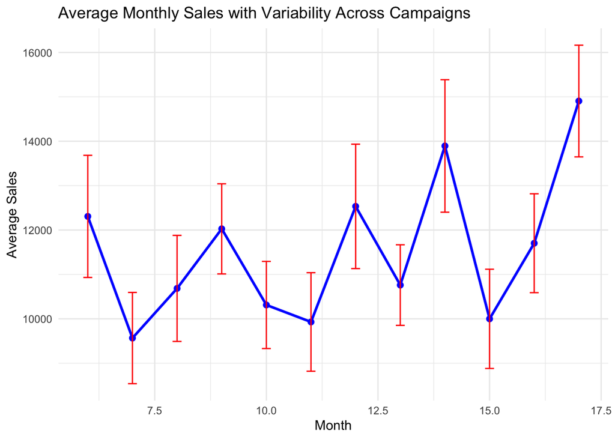

```r
mean_base_sales <- mean(sales_forecasting_data$Base_Sales)
sd_base_sales <- sd(sales_forecasting_data$Base_Sales)


set.seed(42)

new_months <- 6:17
simulated_base_sales <- rnorm(12, mean = mean_base_sales, sd = sd_base_sales)

simulated_sales_data <- data.frame(
  Month = new_months,
  Base_Sales = simulated_base_sales,
  Marketing_Effect = NA,
  Adjusted_Sales = NA
)

sales_data_list <- vector("list", 5)

for (campaign in 1:5) {
  marketing_effect <- runif(12, min = -0.1, max = 0.1)
  simulated_sales_data$Marketing_Effect <- marketing_effect

  for (i in 1:nrow(simulated_sales_data)) {
    simulated_sales_data$Adjusted_Sales[i] <- simulate_sales(simulated_sales_data$Base_Sales[i],
                                                               simulated_sales_data$Marketing_Effect[i])
  }

  sales_data_list[[campaign]] <- simulated_sales_data$Adjusted_Sales
}

sales_data_df <- do.call(cbind, sales_data_list)
colnames(sales_data_df) <- paste("Campaign", 1:5)

average_sales <- rowMeans(sales_data_df, na.rm = TRUE)
sd_sales <- apply(sales_data_df, 1, sd)

plot_data <- data.frame(Month = new_months, Average_Sales = average_sales, SD_Sales = sd_sales)

ggplot(plot_data, aes(x = Month, y = Average_Sales)) +
  geom_line(color = "blue", size = 1) +
  geom_point(color = "blue", size = 2) +
  geom_errorbar(aes(ymin = Average_Sales - SD_Sales, ymax = Average_Sales + SD_Sales),
                width = 0.2, color = "red") +
  labs(title = "Average Monthly Sales with Variability Across Campaigns",
       x = "Month",
       y = "Average Sales") +
  theme_minimal()
```